# ReneWind - Wind Turbine Failure Prediction

## Business Context

Renewable energy and predictive maintenance are central to reducing downtime and operational costs. ReneWind wants to identify generator failures early so components can be repaired before replacement becomes necessary.

## Objective

Build neural-network classification models to predict generator failure (`1` = failure, `0` = no failure), improve performance through multiple modeling strategies, and select the best model using both ML metrics and a cost-aware business criterion.

## Rubric Coverage Map

- EDA: Data overview, univariate, bivariate
- Preprocessing: Missing-value treatment and leakage control
- Baseline NN: SGD optimizer + rationale
- Performance improvement: 6+ experiments using depth/optimizer/dropout/class weights
- Final model: Test-set evaluation and business recommendations

## 1. Environment Setup and Reproducibility

We import required libraries, set random seeds, and define helper utilities for consistent experiment tracking and cost-aware evaluation.

```python
import os
import random
import warnings
import numpy as np
import pandas as pd
import matplotlib.pyplot as plt
import seaborn as sns

from sklearn.model_selection import train_test_split
from sklearn.compose import ColumnTransformer
from sklearn.pipeline import Pipeline
from sklearn.impute import SimpleImputer
from sklearn.preprocessing import StandardScaler, OneHotEncoder
from sklearn.metrics import (
    accuracy_score,
    precision_score,
    recall_score,
    f1_score,
    roc_auc_score,
    average_precision_score,
    confusion_matrix,
    classification_report,
    RocCurveDisplay,
    PrecisionRecallDisplay,
)
from sklearn.utils.class_weight import compute_class_weight

import tensorflow as tf
from tensorflow.keras import Sequential
from tensorflow.keras.layers import Dense, Dropout, Input
from tensorflow.keras.optimizers import SGD, Adam
from tensorflow.keras.callbacks import EarlyStopping

warnings.filterwarnings("ignore")

SEED = 42
random.seed(SEED)
np.random.seed(SEED)
tf.random.set_seed(SEED)

sns.set_theme(style="whitegrid")
plt.rcParams["figure.figsize"] = (10, 5)

print("TensorFlow version:", tf.__version__)
print("Seed set to:", SEED)
```

```
TensorFlow version: 2.21.0
Seed set to: 42
```

```python
# Business cost assumptions (can be updated based on real contracts)
COST_FP = 5    # Inspection cost for false alarm
COST_TP = 20   # Repair cost for correctly predicted failure
COST_FN = 100  # Replacement cost for missed failure


def to_dense(x):
    return x.toarray() if hasattr(x, "toarray") else x


def compute_business_cost(y_true, y_pred):
    tn, fp, fn, tp = confusion_matrix(y_true, y_pred).ravel()
    total_cost = (COST_FN * fn) + (COST_TP * tp) + (COST_FP * fp)
    return {
        "TN": tn,
        "FP": fp,
        "FN": fn,
        "TP": tp,
        "Business_Cost": total_cost,
    }


def evaluate_predictions(y_true, y_prob, threshold=0.5):
    y_pred = (y_prob >= threshold).astype(int)
    stats = {
        "Accuracy": accuracy_score(y_true, y_pred),
        "Precision": precision_score(y_true, y_pred, zero_division=0),
        "Recall": recall_score(y_true, y_pred, zero_division=0),
        "F1": f1_score(y_true, y_pred, zero_division=0),
        "ROC_AUC": roc_auc_score(y_true, y_prob),
        "PR_AUC": average_precision_score(y_true, y_prob),
        "Threshold": threshold,
    }
    stats.update(compute_business_cost(y_true, y_pred))
    return stats


def build_model(input_dim, hidden_layers=(64,), optimizer_name="sgd", dropout_rate=0.0, lr=0.01):
    tf.keras.backend.clear_session()

    model = Sequential()
    model.add(Input(shape=(input_dim,)))

    for units in hidden_layers:
        model.add(Dense(units, activation="relu"))
        if dropout_rate > 0:
            model.add(Dropout(dropout_rate))

    model.add(Dense(1, activation="sigmoid"))

    if optimizer_name.lower() == "adam":
        optimizer = Adam(learning_rate=lr)
    else:
        optimizer = SGD(learning_rate=lr, momentum=0.9)

    model.compile(
        optimizer=optimizer,
        loss="binary_crossentropy",
        metrics=[tf.keras.metrics.AUC(name="auc")],
    )
    return model
```

## 2. Load Train/Test Data from Provided File Paths

We load the transformed confidential sensor datasets and verify schema expectations.

```python
train_path = "/Users/lakshmanraghu/Documents/Great Learning/Project - Neural Networks/datasets/Train.csv"
test_path = "/Users/lakshmanraghu/Documents/Great Learning/Project - Neural Networks/datasets/Test.csv"

train_df = pd.read_csv(train_path)
test_df = pd.read_csv(test_path)

print("Train shape:", train_df.shape)
print("Test shape:", test_df.shape)
print("\nColumns match:", list(train_df.columns) == list(test_df.columns))

possible_targets = ["target", "Target", "failure", "Failure", "y", "label", "Label"]
target_col = next((c for c in possible_targets if c in train_df.columns), train_df.columns[-1])

print("Detected target column:", target_col)
print("Target present in train:", target_col in train_df.columns)
print("Target present in test:", target_col in test_df.columns)

train_df.head()
```

```
Train shape: (20000, 41)
Test shape: (5000, 41)

Columns match: True
Detected target column: Target
Target present in train: True
Target present in test: True
```

|  | V1 | V2 | V3 | V4 | V5 | V6 | V7 | V8 | V9 | V10 | ... | V32 | V33 | V34 | V35 | V36 | V37 | V38 | V39 | V40 | Target |
| --- | --- | --- | --- | --- | --- | --- | --- | --- | --- | --- | --- | --- | --- | --- | --- | --- | --- | --- | --- | --- | --- |
| 0 | -4.464606 | -4.679129 | 3.101546 | 0.506130 | -0.221083 | -2.032511 | -2.910870 | 0.050714 | -1.522351 | 3.761892 | ... | 3.059700 | -1.690440 | 2.846296 | 2.235198 | 6.667486 | 0.443809 | -2.369169 | 2.950578 | -3.480324 | 0 |
| 1 | 3.365912 | 3.653381 | 0.909671 | -1.367528 | 0.332016 | 2.358938 | 0.732600 | -4.332135 | 0.565695 | -0.101080 | ... | -1.795474 | 3.032780 | -2.467514 | 1.894599 | -2.297780 | -1.731048 | 5.908837 | -0.386345 | 0.616242 | 0 |
| 2 | -3.831843 | -5.824444 | 0.634031 | -2.418815 | -1.773827 | 1.016824 | -2.098941 | -3.173204 | -2.081860 | 5.392621 | ... | -0.257101 | 0.803550 | 4.086219 | 2.292138 | 5.360850 | 0.351993 | 2.940021 | 3.839160 | -4.309402 | 0 |
| 3 | 1.618098 | 1.888342 | 7.046143 | -1.147285 | 0.083080 | -1.529780 | 0.207309 | -2.493629 | 0.344926 | 2.118578 | ... | -3.584425 | -2.577474 | 1.363769 | 0.622714 | 5.550100 | -1.526796 | 0.138853 | 3.101430 | -1.277378 | 0 |
| 4 | -0.111440 | 3.872488 | -3.758361 | -2.982897 | 3.792714 | 0.544960 | 0.205433 | 4.848994 | -1.854920 | -6.220023 | ... | 8.265896 | 6.629213 | -10.068689 | 1.222987 | -3.229763 | 1.686909 | -2.163896 | -3.644622 | 6.510338 | 0 |

5 rows × 41 columns

## 3. Data Overview and Target Distribution

This section checks structure, data quality, duplicates, and target imbalance.

```
Train info:
<class 'pandas.DataFrame'>
RangeIndex: 20000 entries, 0 to 19999
Data columns (total 41 columns):
 #   Column  Non-Null Count  Dtype
---  ------  --------------  -----
 0   V1      19982 non-null  float64
 1   V2      19982 non-null  float64
 2   V3      20000 non-null  float64
 3   V4      20000 non-null  float64
 4   V5      20000 non-null  float64
 5   V6      20000 non-null  float64
 6   V7      20000 non-null  float64
 7   V8      20000 non-null  float64
 8   V9      20000 non-null  float64
```

[output cut: 34 more lines]

```
None
```

```
Missing values (top 10):
```

```
V1     18
V2     18
V40     0
V30     0
V23     0
V24     0
V25     0
V26     0
V27     0
V28     0
dtype: int64
```

```
Duplicate rows in train: 0

Summary statistics:
```

|  | count | mean | std | min | 25% | 50% | 75% | max |
| --- | --- | --- | --- | --- | --- | --- | --- | --- |
| V1 | 19982.0 | -0.271996 | 3.441625 | -11.876451 | -2.737146 | -0.747917 | 1.840112 | 15.493002 |
| V2 | 19982.0 | 0.440430 | 3.150784 | -12.319951 | -1.640674 | 0.471536 | 2.543967 | 13.089269 |
| V3 | 20000.0 | 2.484699 | 3.388963 | -10.708139 | 0.206860 | 2.255786 | 4.566165 | 17.090919 |
| V4 | 20000.0 | -0.083152 | 3.431595 | -15.082052 | -2.347660 | -0.135241 | 2.130615 | 13.236381 |
| V5 | 20000.0 | -0.053752 | 2.104801 | -8.603361 | -1.535607 | -0.101952 | 1.340480 | 8.133797 |
| V6 | 20000.0 | -0.995443 | 2.040970 | -10.227147 | -2.347238 | -1.000515 | 0.380330 | 6.975847 |
| V7 | 20000.0 | -0.879325 | 1.761626 | -7.949681 | -2.030926 | -0.917179 | 0.223695 | 8.006091 |
| V8 | 20000.0 | -0.548195 | 3.295756 | -15.657561 | -2.642665 | -0.389085 | 1.722965 | 11.679495 |
| V9 | 20000.0 | -0.016808 | 2.160568 | -8.596313 | -1.494973 | -0.067597 | 1.409203 | 8.137580 |
| V10 | 20000.0 | -0.012998 | 2.193201 | -9.853957 | -1.411212 | 0.100973 | 1.477045 | 8.108472 |

```
Target distribution (counts):
```

```
Target
0    18890
1     1110
Name: count, dtype: int64
```

```
Target distribution (%):
```

```
Target
0    94.45
1     5.55
Name: proportion, dtype: float64
```

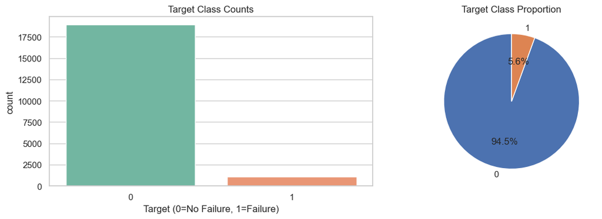

```
Imbalance ratio (majority/minority): 17.02
```

```python
print("Train info:")
display(train_df.info())

print("\nMissing values (top 10):")
display(train_df.isna().sum().sort_values(ascending=False).head(10))

duplicates = train_df.duplicated().sum()
print("\nDuplicate rows in train:", duplicates)

print("\nSummary statistics:")
display(train_df.describe().T.head(10))

target_dist = train_df[target_col].value_counts().sort_index()
target_pct = train_df[target_col].value_counts(normalize=True).sort_index() * 100

print("\nTarget distribution (counts):")
display(target_dist)
print("\nTarget distribution (%):")
display(target_pct.round(2))

fig, axes = plt.subplots(1, 2, figsize=(12, 4))
sns.countplot(x=target_col, data=train_df, ax=axes[0], palette="Set2")
axes[0].set_title("Target Class Counts")
axes[0].set_xlabel("Target (0=No Failure, 1=Failure)")

axes[1].pie(target_dist.values, labels=target_dist.index, autopct="%1.1f%%", startangle=90)
axes[1].set_title("Target Class Proportion")
plt.tight_layout()
plt.show()

imbalance_ratio = target_dist.max() / target_dist.min()
print(f"Imbalance ratio (majority/minority): {imbalance_ratio:.2f}")
```

## 4. Univariate Analysis of Sensor Features

We inspect distributions and outliers for a subset of representative numeric predictors.

```
Numeric predictors: 40
Categorical predictors: 0
```

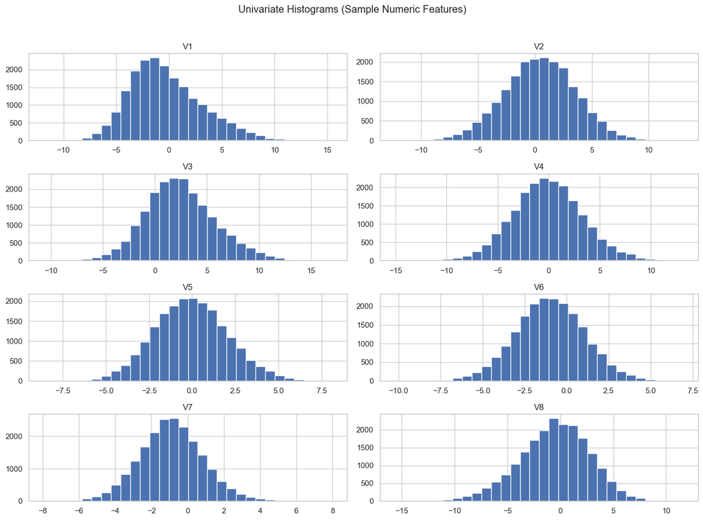

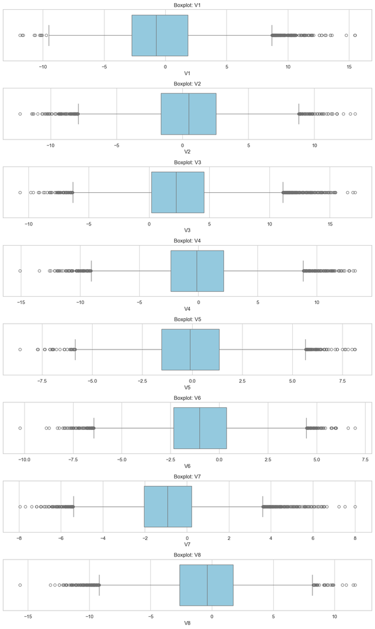

|  | mean | std | min | 25% | 50% | 75% | max |
| --- | --- | --- | --- | --- | --- | --- | --- |
| V1 | -0.271996 | 3.441625 | -11.876451 | -2.737146 | -0.747917 | 1.840112 | 15.493002 |
| V2 | 0.440430 | 3.150784 | -12.319951 | -1.640674 | 0.471536 | 2.543967 | 13.089269 |
| V3 | 2.484699 | 3.388963 | -10.708139 | 0.206860 | 2.255786 | 4.566165 | 17.090919 |
| V4 | -0.083152 | 3.431595 | -15.082052 | -2.347660 | -0.135241 | 2.130615 | 13.236381 |
| V5 | -0.053752 | 2.104801 | -8.603361 | -1.535607 | -0.101952 | 1.340480 | 8.133797 |
| V6 | -0.995443 | 2.040970 | -10.227147 | -2.347238 | -1.000515 | 0.380330 | 6.975847 |
| V7 | -0.879325 | 1.761626 | -7.949681 | -2.030926 | -0.917179 | 0.223695 | 8.006091 |
| V8 | -0.548195 | 3.295756 | -15.657561 | -2.642665 | -0.389085 | 1.722965 | 11.679495 |

```python
feature_cols = [c for c in train_df.columns if c != target_col]
numeric_cols = train_df[feature_cols].select_dtypes(include=[np.number]).columns.tolist()
cat_cols = [c for c in feature_cols if c not in numeric_cols]

print(f"Numeric predictors: {len(numeric_cols)}")
print(f"Categorical predictors: {len(cat_cols)}")

sample_num_cols = numeric_cols[:8] if len(numeric_cols) >= 8 else numeric_cols

if sample_num_cols:
    train_df[sample_num_cols].hist(bins=30, figsize=(14, 10), layout=(4, 2))
    plt.suptitle("Univariate Histograms (Sample Numeric Features)", y=1.02)
    plt.tight_layout()
    plt.show()

    fig, axes = plt.subplots(len(sample_num_cols), 1, figsize=(12, 2.5 * len(sample_num_cols)))
    if len(sample_num_cols) == 1:
        axes = [axes]
    for ax, col in zip(axes, sample_num_cols):
        sns.boxplot(x=train_df[col], ax=ax, color="skyblue")
        ax.set_title(f"Boxplot: {col}")
    plt.tight_layout()
    plt.show()

    uni_stats = train_df[sample_num_cols].describe().T[["mean", "std", "min", "25%", "50%", "75%", "max"]]
    display(uni_stats)
```

## 5. Bivariate Analysis Against Failure Target

We compare feature behavior across failure classes and inspect correlation patterns.

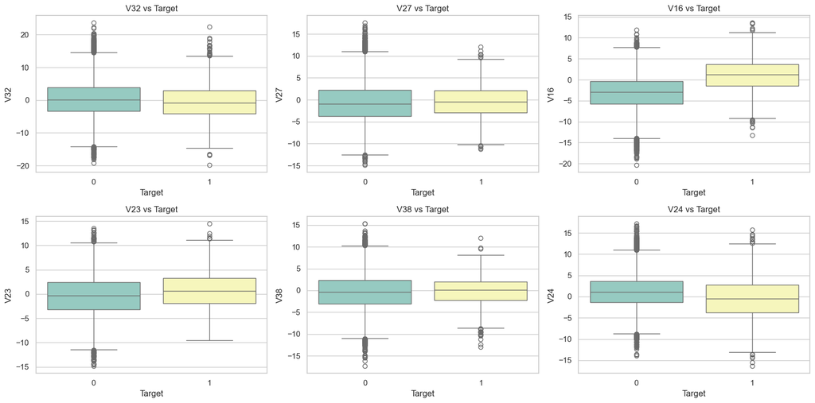

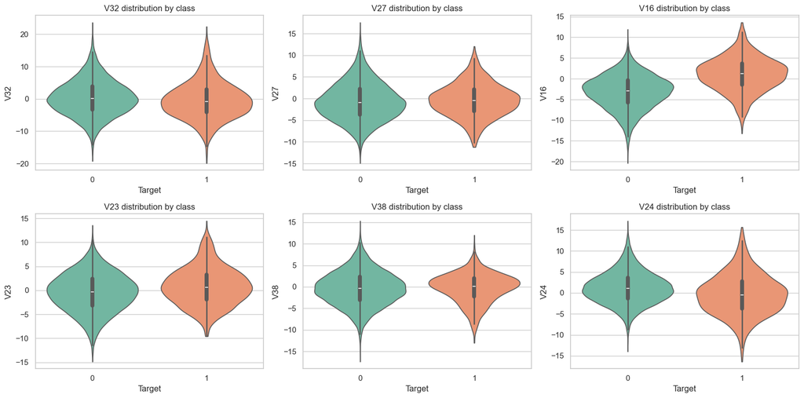

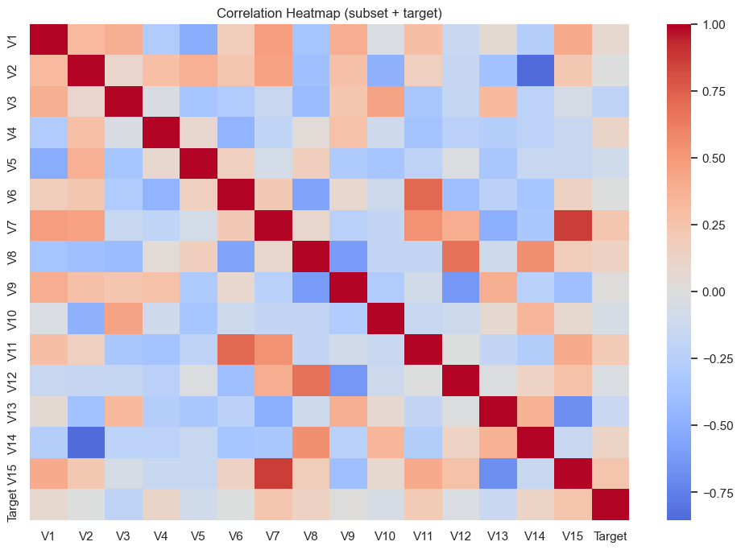

```
Top absolute correlations with target:
```

```
V15    0.249118
V7     0.236907
V3    -0.213855
V11    0.196715
V13   -0.139718
V8     0.135996
V14    0.117586
V4     0.110786
V5    -0.100525
V1     0.073307
Name: Target, dtype: float64
```

```python
top_var_cols = train_df[numeric_cols].var().sort_values(ascending=False).head(6).index.tolist() if numeric_cols else []

if top_var_cols:
    fig, axes = plt.subplots(2, 3, figsize=(16, 8))
    axes = axes.flatten()
    for i, col in enumerate(top_var_cols):
        sns.boxplot(data=train_df, x=target_col, y=col, ax=axes[i], palette="Set3")
        axes[i].set_title(f"{col} vs Target")
    for j in range(i + 1, len(axes)):
        axes[j].axis("off")
    plt.tight_layout()
    plt.show()

    fig, axes = plt.subplots(2, 3, figsize=(16, 8))
    axes = axes.flatten()
    for i, col in enumerate(top_var_cols):
        sns.violinplot(data=train_df, x=target_col, y=col, ax=axes[i], palette="Set2", cut=0)
        axes[i].set_title(f"{col} distribution by class")
    for j in range(i + 1, len(axes)):
        axes[j].axis("off")
    plt.tight_layout()
    plt.show()

corr_subset = numeric_cols[:15] if len(numeric_cols) > 15 else numeric_cols
if corr_subset:
    corr_df = train_df[corr_subset + [target_col]].corr()
    plt.figure(figsize=(12, 8))
    sns.heatmap(corr_df, cmap="coolwarm", center=0)
    plt.title("Correlation Heatmap (subset + target)")
    plt.show()

if corr_subset:
    target_corr = corr_df[target_col].drop(target_col).sort_values(key=np.abs, ascending=False)
    print("Top absolute correlations with target:")
    display(target_corr.head(10))
```

## 6. Preprocessing Pipeline (Missing Values, Scaling, Leakage Control)

We split training data into train/validation using stratification, fit preprocessing on train split only, and transform validation/test without leakage.

```python
X = train_df.drop(columns=[target_col]).copy()
y = train_df[target_col].astype(int).copy()

X_test_final = test_df.drop(columns=[target_col]).copy()
y_test_final = test_df[target_col].astype(int).copy()

X_train_raw, X_val_raw, y_train, y_val = train_test_split(
    X,
    y,
    test_size=0.2,
    random_state=SEED,
    stratify=y,
)

numeric_features = X_train_raw.select_dtypes(include=[np.number]).columns.tolist()
categorical_features = [c for c in X_train_raw.columns if c not in numeric_features]

numeric_transformer = Pipeline(
    steps=[
        ("imputer", SimpleImputer(strategy="median")),
        ("scaler", StandardScaler()),
    ]
)

categorical_transformer = Pipeline(
    steps=[
        ("imputer", SimpleImputer(strategy="most_frequent")),
        ("onehot", OneHotEncoder(handle_unknown="ignore")),
    ]
)

preprocessor = ColumnTransformer(
    transformers=[
        ("num", numeric_transformer, numeric_features),
        ("cat", categorical_transformer, categorical_features),
    ]
)

X_train_proc = to_dense(preprocessor.fit_transform(X_train_raw))
X_val_proc = to_dense(preprocessor.transform(X_val_raw))
X_test_proc = to_dense(preprocessor.transform(X_test_final))

print("Train split shape:", X_train_raw.shape)
print("Validation split shape:", X_val_raw.shape)
print("Processed train shape:", X_train_proc.shape)
print("Processed validation shape:", X_val_proc.shape)
print("Processed test shape:", X_test_proc.shape)
```

```
Train split shape: (16000, 40)
Validation split shape: (4000, 40)
Processed train shape: (16000, 40)
Processed validation shape: (4000, 40)
Processed test shape: (5000, 40)
```

## 7. Metric Design with Cost-Sensitive Rationale

Accuracy alone is insufficient for predictive maintenance. We prioritize:

- **Recall (class 1)** to reduce missed failures (false negatives)
- **F1** for precision-recall balance
- **PR-AUC** for minority/failure detection quality
- **Business Cost** where $C_{FN} > C_{TP} > C_{FP}$

We use: $$ \text{Cost} = C_{FN}\cdot FN + C_{TP}\cdot TP + C_{FP}\cdot FP $$ with $C_{FN}=100$, $C_{TP}=20$, $C_{FP}=5$.

```python
def run_experiment(name, hidden_layers, optimizer_name, dropout_rate, class_weight=None, lr=0.01, epochs=30):
    model = build_model(
        input_dim=X_train_proc.shape[1],
        hidden_layers=hidden_layers,
        optimizer_name=optimizer_name,
        dropout_rate=dropout_rate,
        lr=lr,
    )

    early_stop = EarlyStopping(
        monitor="val_loss",
        mode="min",
        patience=4,
        restore_best_weights=True,
        verbose=0,
    )

    history = model.fit(
        X_train_proc,
        y_train,
        validation_data=(X_val_proc, y_val),
        epochs=epochs,
        batch_size=256,
        verbose=0,
        callbacks=[early_stop],
        class_weight=class_weight,
    )

    y_val_prob = model.predict(X_val_proc, verbose=0).ravel()
    stats = evaluate_predictions(y_val, y_val_prob, threshold=0.5)
    stats["Model"] = name
    stats["Layers"] = str(hidden_layers)
    stats["Optimizer"] = optimizer_name
    stats["Dropout"] = dropout_rate
    stats["Class_Weight"] = "Yes" if class_weight else "No"
    stats["Best_Epoch"] = int(np.argmin(history.history["val_loss"]) + 1)

    return model, history, stats, y_val_prob


class_weights_vals = compute_class_weight(
    class_weight="balanced",
    classes=np.unique(y_train),
    y=y_train,
)
class_weight_dict = {int(k): float(v) for k, v in zip(np.unique(y_train), class_weights_vals)}

print("Class weights:", class_weight_dict)
print(f"Cost formula uses FN={COST_FN}, TP={COST_TP}, FP={COST_FP}")
```

```
Class weights: {0: 0.5293806246691372, 1: 9.00900900900901}
Cost formula uses FN=100, TP=20, FP=5
```

## 8. Baseline Neural Network (SGD Optimizer)

Baseline architecture: one hidden layer using SGD optimizer, with early stopping.

```python
models = {}
histories = {}
val_probs = {}
results = []

baseline_model, baseline_hist, baseline_stats, baseline_prob = run_experiment(
    name="Baseline_SGD",
    hidden_layers=(64,),
    optimizer_name="sgd",
    dropout_rate=0.0,
    class_weight=None,
    lr=0.01,
)

models["Baseline_SGD"] = baseline_model
histories["Baseline_SGD"] = baseline_hist
val_probs["Baseline_SGD"] = baseline_prob
results.append(baseline_stats)

display(pd.DataFrame([baseline_stats]).set_index("Model"))

# Threshold behavior snapshot
for th in [0.30, 0.50, 0.70]:
    th_stats = evaluate_predictions(y_val, baseline_prob, threshold=th)
    print(
        f"Threshold={th:.2f} | Recall={th_stats['Recall']:.3f} | "
        f"Precision={th_stats['Precision']:.3f} | FN={th_stats['FN']} | Cost={th_stats['Business_Cost']}"
    )
```

| Model | Accuracy | Precision | Recall | F1 | ROC_AUC | PR_AUC | Threshold | TN | FP | FN | TP | Business_Cost | Layers | Optimizer | Dropout | Class_Weight | Best_Epoch |
| --- | --- | --- | --- | --- | --- | --- | --- | --- | --- | --- | --- | --- | --- | --- | --- | --- | --- |
| Baseline_SGD | 0.9895 | 0.98913 | 0.81982 | 0.896552 | 0.939969 | 0.913524 | 0.5 | 3776 | 2 | 40 | 182 | 7650 | (64,) | sgd | 0.0 | No | 30 |

```
Threshold=0.30 | Recall=0.883 | Precision=0.951 | FN=26 | Cost=6570
Threshold=0.50 | Recall=0.820 | Precision=0.989 | FN=40 | Cost=7650
Threshold=0.70 | Recall=0.730 | Precision=0.994 | FN=60 | Cost=9245
```

## 9-14. Model Performance Improvement Experiments

We run six required improvement experiments using combinations of:

- more hidden layers
- optimizer change (SGD/Adam)
- dropout
- class weights

```python
experiment_configs = [
    {
        "name": "Exp1_MoreLayers_SGD",
        "hidden_layers": (128, 64),
        "optimizer_name": "sgd",
        "dropout_rate": 0.0,
        "class_weight": None,
        "lr": 0.01,
        "note": "More hidden layers with SGD",
    },
    {
        "name": "Exp2_Adam",
        "hidden_layers": (64,),
        "optimizer_name": "adam",
        "dropout_rate": 0.0,
        "class_weight": None,
        "lr": 0.001,
        "note": "Optimizer changed from SGD to Adam",
    },
    {
        "name": "Exp3_Dropout",
        "hidden_layers": (64,),
        "optimizer_name": "adam",
        "dropout_rate": 0.3,
        "class_weight": None,
        "lr": 0.001,
        "note": "Dropout regularization",
    },
    {
        "name": "Exp4_ClassWeights",
        "hidden_layers": (64,),
        "optimizer_name": "adam",
        "dropout_rate": 0.0,
        "class_weight": class_weight_dict,
        "lr": 0.001,
        "note": "Class weights for imbalance",
    },
    {
        "name": "Exp5_MoreLayers_Adam_Dropout",
        "hidden_layers": (128, 64),
        "optimizer_name": "adam",
        "dropout_rate": 0.3,
        "class_weight": None,
        "lr": 0.001,
        "note": "Deeper model + Adam + dropout",
    },
    {
        "name": "Exp6_AllCombined",
        "hidden_layers": (128, 64, 32),
        "optimizer_name": "adam",
        "dropout_rate": 0.3,
        "class_weight": class_weight_dict,
        "lr": 0.001,
        "note": "Depth + Adam + dropout + class weights",
    },
]

for cfg in experiment_configs:
    model, hist, stats, y_prob = run_experiment(
        name=cfg["name"],
        hidden_layers=cfg["hidden_layers"],
        optimizer_name=cfg["optimizer_name"],
        dropout_rate=cfg["dropout_rate"],
        class_weight=cfg["class_weight"],
        lr=cfg["lr"],
    )
    stats["Note"] = cfg["note"]

    models[cfg["name"]] = model
    histories[cfg["name"]] = hist
    val_probs[cfg["name"]] = y_prob
    results.append(stats)

    print(f"Completed: {cfg['name']}")
    print(
        f"Recall={stats['Recall']:.3f}, F1={stats['F1']:.3f}, "
        f"PR_AUC={stats['PR_AUC']:.3f}, FN={stats['FN']}, Cost={stats['Business_Cost']}"
    )
    print("-" * 80)
```

```
Completed: Exp1_MoreLayers_SGD
Recall=0.865, F1=0.921, PR_AUC=0.921, FN=30, Cost=6855
--------------------------------------------------------------------------------
Completed: Exp2_Adam
Recall=0.820, F1=0.897, PR_AUC=0.918, FN=40, Cost=7650
--------------------------------------------------------------------------------
Completed: Exp3_Dropout
Recall=0.802, F1=0.888, PR_AUC=0.916, FN=44, Cost=7965
--------------------------------------------------------------------------------
Completed: Exp4_ClassWeights
Recall=0.914, F1=0.806, PR_AUC=0.917, FN=19, Cost=6355
--------------------------------------------------------------------------------
Completed: Exp5_MoreLayers_Adam_Dropout
Recall=0.905, F1=0.944, PR_AUC=0.927, FN=21, Cost=6135
--------------------------------------------------------------------------------
Completed: Exp6_AllCombined
Recall=0.914, F1=0.919, PR_AUC=0.925, FN=19, Cost=6045
--------------------------------------------------------------------------------
```

## 15. Experiment Tracking, Comparison, and Best Model Selection

Primary selection criterion: **minimum business cost**, with **high recall for failure class** and strong PR-AUC as tie-breakers.

```python
results_df = pd.DataFrame(results)
cols_order = [
    "Model", "Layers", "Optimizer", "Dropout", "Class_Weight", "Best_Epoch",
    "Accuracy", "Precision", "Recall", "F1", "ROC_AUC", "PR_AUC",
    "FN", "FP", "TP", "TN", "Business_Cost", "Note"
]
results_df = results_df[cols_order].sort_values(by=["Business_Cost", "FN", "PR_AUC"], ascending=[True, True, False])

display(results_df.style.background_gradient(subset=["Recall", "F1", "PR_AUC"], cmap="Greens"))

best_model_name = results_df.iloc[0]["Model"]
print("Selected best model:", best_model_name)
print("Selection rationale: lowest business cost with strong failure recall and PR-AUC.")
```

|  | Model | Layers | Optimizer | Dropout | Class_Weight | Best_Epoch | Accuracy | Precision | Recall | F1 | ROC_AUC | PR_AUC | FN | FP | TP | TN | Business_Cost | Note |
| --- | --- | --- | --- | --- | --- | --- | --- | --- | --- | --- | --- | --- | --- | --- | --- | --- | --- | --- |
| 6 | Exp6_AllCombined | (128, 64, 32) | adam | 0.300000 | Yes | 24 | 0.991000 | 0.922727 | 0.914414 | 0.918552 | 0.959901 | 0.925199 | 19 | 17 | 203 | 3761 | 6045 | Depth + Adam + dropout + class weights |
| 5 | Exp5_MoreLayers_Adam_Dropout | (128, 64) | adam | 0.300000 | No | 27 | 0.994000 | 0.985294 | 0.905405 | 0.943662 | 0.957603 | 0.926871 | 21 | 3 | 201 | 3775 | 6135 | Deeper model + Adam + dropout |
| 4 | Exp4_ClassWeights | (64,) | adam | 0.000000 | Yes | 30 | 0.975500 | 0.719858 | 0.914414 | 0.805556 | 0.947254 | 0.916580 | 19 | 79 | 203 | 3699 | 6355 | Class weights for imbalance |
| 1 | Exp1_MoreLayers_SGD | (128, 64) | sgd | 0.000000 | No | 30 | 0.991750 | 0.984615 | 0.864865 | 0.920863 | 0.947017 | 0.920756 | 30 | 3 | 192 | 3775 | 6855 | More hidden layers with SGD |
| 2 | Exp2_Adam | (64,) | adam | 0.000000 | No | 30 | 0.989500 | 0.989130 | 0.819820 | 0.896552 | 0.941533 | 0.917645 | 40 | 2 | 182 | 3776 | 7650 | Optimizer changed from SGD to Adam |
| 0 | Baseline_SGD | (64,) | sgd | 0.000000 | No | 30 | 0.989500 | 0.989130 | 0.819820 | 0.896552 | 0.939969 | 0.913524 | 40 | 2 | 182 | 3776 | 7650 | nan |
| 3 | Exp3_Dropout | (64,) | adam | 0.300000 | No | 30 | 0.988750 | 0.994413 | 0.801802 | 0.887781 | 0.940297 | 0.916192 | 44 | 1 | 178 | 3777 | 7965 | Dropout regularization |

```
Selected best model: Exp6_AllCombined
Selection rationale: lowest business cost with strong failure recall and PR-AUC.
```

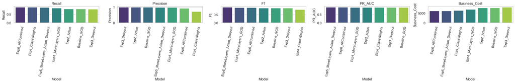

```python
# Visual comparison for key metrics
plot_df = results_df.copy()
metrics_plot = ["Recall", "Precision", "F1", "PR_AUC", "Business_Cost"]

fig, axes = plt.subplots(1, len(metrics_plot), figsize=(24, 4))
for ax, metric in zip(axes, metrics_plot):
    sorted_df = plot_df.sort_values(metric, ascending=(metric == "Business_Cost"))
    sns.barplot(data=sorted_df, x="Model", y=metric, ax=ax, palette="viridis")
    ax.set_xticklabels(ax.get_xticklabels(), rotation=80)
    ax.set_title(metric)
plt.tight_layout()
plt.show()
```

## 16. Final Test-Set Evaluation and Error-Cost Analysis

We retrain the selected architecture using full training data (Train.csv), then evaluate exactly once on Test.csv.

```python
best_row = results_df.loc[results_df["Model"] == best_model_name].iloc[0]

# Refit preprocessor on full training data (no test leakage)
X_full = train_df.drop(columns=[target_col]).copy()
y_full = train_df[target_col].astype(int).copy()

X_test_holdout = test_df.drop(columns=[target_col]).copy()
y_test_holdout = test_df[target_col].astype(int).copy()

num_full = X_full.select_dtypes(include=[np.number]).columns.tolist()
cat_full = [c for c in X_full.columns if c not in num_full]

full_preprocessor = ColumnTransformer(
    transformers=[
        ("num", Pipeline([
            ("imputer", SimpleImputer(strategy="median")),
            ("scaler", StandardScaler()),
        ]), num_full),
        ("cat", Pipeline([
            ("imputer", SimpleImputer(strategy="most_frequent")),
            ("onehot", OneHotEncoder(handle_unknown="ignore")),
        ]), cat_full),
    ]
)

X_full_proc = to_dense(full_preprocessor.fit_transform(X_full))
X_test_holdout_proc = to_dense(full_preprocessor.transform(X_test_holdout))

final_model = build_model(
    input_dim=X_full_proc.shape[1],
    hidden_layers=eval(best_row["Layers"]),
    optimizer_name=best_row["Optimizer"],
    dropout_rate=float(best_row["Dropout"]),
    lr=0.001 if str(best_row["Optimizer"]).lower() == "adam" else 0.01,
)

final_class_weight = class_weight_dict if best_row["Class_Weight"] == "Yes" else None

final_es = EarlyStopping(monitor="val_loss", mode="min", patience=4, restore_best_weights=True, verbose=0)

X_subtrain, X_subval, y_subtrain, y_subval = train_test_split(
    X_full_proc, y_full, test_size=0.15, random_state=SEED, stratify=y_full
)

final_history = final_model.fit(
    X_subtrain,
    y_subtrain,
    validation_data=(X_subval, y_subval),
    epochs=35,
    batch_size=256,
    verbose=0,
    callbacks=[final_es],
    class_weight=final_class_weight,
)

y_test_prob = final_model.predict(X_test_holdout_proc, verbose=0).ravel()
final_test_stats = evaluate_predictions(y_test_holdout, y_test_prob, threshold=0.5)

print("Final Test Metrics:")
for k in ["Accuracy", "Precision", "Recall", "F1", "ROC_AUC", "PR_AUC", "FN", "FP", "TP", "TN", "Business_Cost"]:
    v = final_test_stats[k]
    if isinstance(v, float):
        print(f"{k}: {v:.4f}")
    else:
        print(f"{k}: {v}")

print("\nClassification Report (Test):")
print(classification_report(y_test_holdout, (y_test_prob >= 0.5).astype(int), digits=4))
```

```
Final Test Metrics:
Accuracy: 0.9882
Precision: 0.9114
Recall: 0.8759
F1: 0.8933
ROC_AUC: 0.9385
PR_AUC: 0.8940
FN: 35
FP: 24
TP: 247
TN: 4694
Business_Cost: 8560

Classification Report (Test):
              precision    recall  f1-score   support

           0     0.9926    0.9949    0.9938      4718
           1     0.9114    0.8759    0.8933       282

    accuracy                         0.9882      5000
   macro avg     0.9520    0.9354    0.9435      5000
weighted avg     0.9880    0.9882    0.9881      5000
```

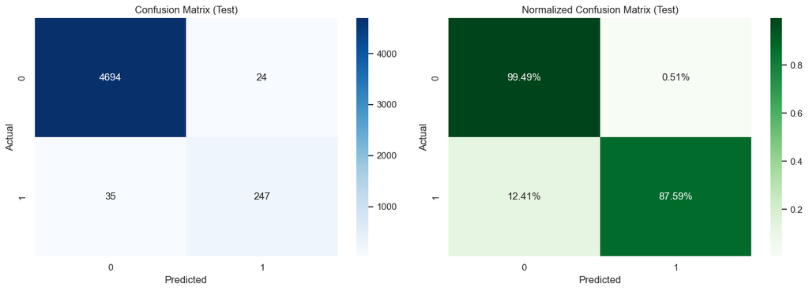

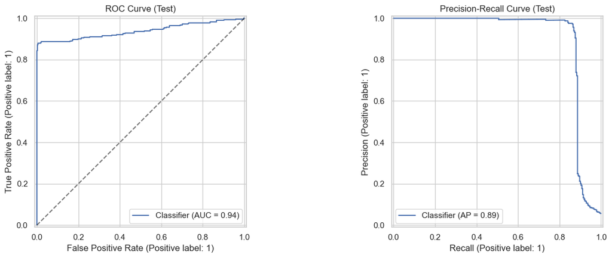

```
Cost interpretation:
Total modeled operational cost on Test set = 8560
Lower is better. FN is heavily penalized to reflect expensive unplanned replacement.
```

```python
y_test_pred = (y_test_prob >= 0.5).astype(int)
cm = confusion_matrix(y_test_holdout, y_test_pred)

fig, axes = plt.subplots(1, 2, figsize=(14, 5))
sns.heatmap(cm, annot=True, fmt="d", cmap="Blues", ax=axes[0])
axes[0].set_title("Confusion Matrix (Test)")
axes[0].set_xlabel("Predicted")
axes[0].set_ylabel("Actual")

cm_norm = confusion_matrix(y_test_holdout, y_test_pred, normalize="true")
sns.heatmap(cm_norm, annot=True, fmt=".2%", cmap="Greens", ax=axes[1])
axes[1].set_title("Normalized Confusion Matrix (Test)")
axes[1].set_xlabel("Predicted")
axes[1].set_ylabel("Actual")
plt.tight_layout()
plt.show()

fig, axes = plt.subplots(1, 2, figsize=(14, 5))
RocCurveDisplay.from_predictions(y_test_holdout, y_test_prob, ax=axes[0])
axes[0].plot([0, 1], [0, 1], "k--", alpha=0.6)
axes[0].set_title("ROC Curve (Test)")

PrecisionRecallDisplay.from_predictions(y_test_holdout, y_test_prob, ax=axes[1])
axes[1].set_title("Precision-Recall Curve (Test)")
plt.tight_layout()
plt.show()

print("Cost interpretation:")
print(f"Total modeled operational cost on Test set = {final_test_stats['Business_Cost']}")
print("Lower is better. FN is heavily penalized to reflect expensive unplanned replacement.")
```

## 17. Actionable Recommendations from Model Outputs

### Maintenance Actions

1. Use model predictions to trigger **proactive repair workflow** for high-risk turbines (predicted failure = 1).
2. Prioritize inspection queues by predicted probability; inspect highest-risk units first.
3. Treat false negatives as the most critical error because missed failures drive replacement cost.

### Threshold and Cost Policy

1. If business prefers fewer missed failures, lower threshold below 0.50 and accept more inspections.
2. Recalibrate threshold monthly based on latest repair/replacement/inspection cost ratios.
3. Monitor FN trend as a leading KPI for reliability risk.

### Model Governance

1. Track data drift in sensor distributions and class balance.
2. Retrain periodically (e.g., monthly/quarterly) or when performance drops.
3. Maintain a champion-challenger setup using the best current model versus new experimental variants.

### Conclusion

A cost-sensitive neural-network framework was built with leakage-safe preprocessing, multiple architecture/optimizer/regularization experiments, and test-set validation. The selected model provides an actionable basis for reducing high-cost failures through earlier intervention.